```python
%load_ext autoreload
%autoreload 2
```

# Build a baseline model

We are interested in testing the following alternative hypothesis:

1. Higher square footage increases home sale price.
2. The house filling a higher proportion of the overall lot decreases home sale price
3. The cost per square foot is lower in duplexes than in single-family homes

Therefore we have decided that our baseline model should include the following features:

1. Total living space, squarefeet
2. Total lot size, squarefeet
3. The ratio of house footprint to lot size. To engineer this feature we assumed the footprint was reasonably represented by the attached garage space+the first floor square feet divided by the lot size.
4. If the house is a duplex, or not

## Cleaning Thought Process

Some top level thoughts are: we removed sales below 100,000 USD, as these are most likely erroneous or a result from a sale from family to family.

```python
from src.utilities import kc_housing as kc
df = kc.pullsqldata()
df_clean = kc.clean_data_intial(df)
x = df_clean.drop(columns = 'saleprice')
y = df_clean['saleprice']
```

```python
baseline_features = ['sqfttotliving','sqftlot','footprint_ratio','duplex']
kc.make_housing_model(baseline_features, x, y)
```

OLS Regression Results

| Dep. Variable: | saleprice | R-squared: | 0.320 |
| --- | --- | --- | --- |
| Model: | OLS | Adj. R-squared: | 0.320 |
| Method: | Least Squares | F-statistic: | 3277. |
| Date: | Fri, 06 Dec 2019 | Prob (F-statistic): | 0.00 |
| Time: | 11:40:05 | Log-Likelihood: | -3.8999e+05 |
| No. Observations: | 27811 | AIC: | 7.800e+05 |
| Df Residuals: | 27806 | BIC: | 7.800e+05 |
| Df Model: | 4 |  |  |
| Covariance Type: | nonrobust |  |  |

|  | coef | std err | t | P>\|t\| | [0.025 | 0.975] |
| --- | --- | --- | --- | --- | --- | --- |
| const | 1.829e+05 | 6116.942 | 29.901 | 0.000 | 1.71e+05 | 1.95e+05 |
| sqfttotliving | 229.3442 | 2.135 | 107.427 | 0.000 | 225.160 | 233.529 |
| sqftlot | -0.2187 | 0.158 | -1.386 | 0.166 | -0.528 | 0.091 |
| footprint_ratio | 2.606e+05 | 1.77e+04 | 14.734 | 0.000 | 2.26e+05 | 2.95e+05 |
| duplex | 6.572e+04 | 1.62e+04 | 4.061 | 0.000 | 3.4e+04 | 9.74e+04 |

| Omnibus: | 3179.338 | Durbin-Watson: | 0.870 |
| --- | --- | --- | --- |
| Prob(Omnibus): | 0.000 | Jarque-Bera (JB): | 5538.299 |
| Skew: | 0.782 | Prob(JB): | 0.00 |
| Kurtosis: | 4.527 | Cond. No. | 1.78e+05 |

Warnings:  
[1] Standard Errors assume that the covariance matrix of the errors is correctly specified.  
[2] The condition number is large, 1.78e+05. This might indicate that there are  
strong multicollinearity or other numerical problems.

### Check baseline model assumptions

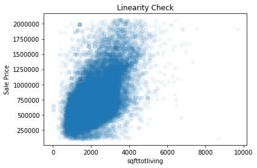

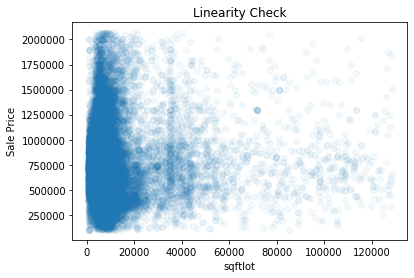

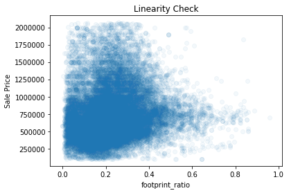

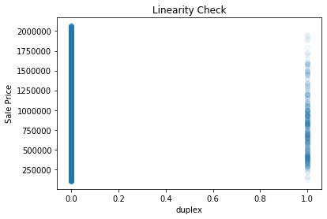

```python
kc.check_feature_linearity(baseline_features, x, y)
```

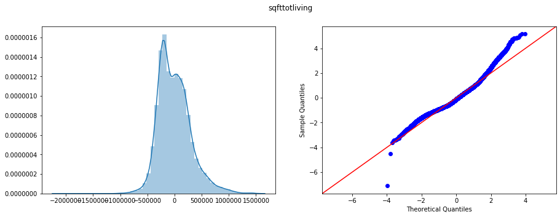

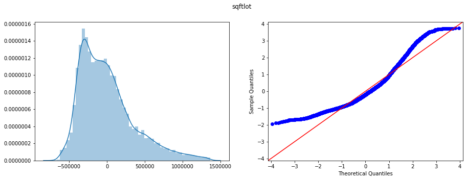

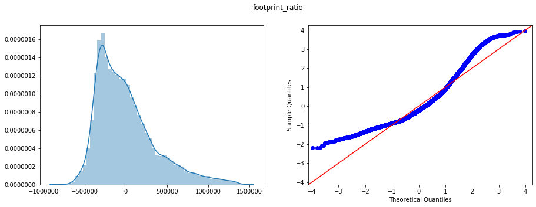

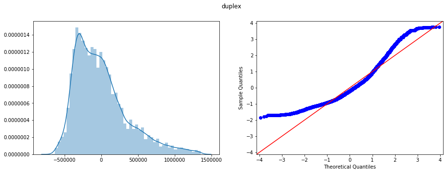

```python
kc.check_feature_resid_dist(baseline_features, x, y)
```

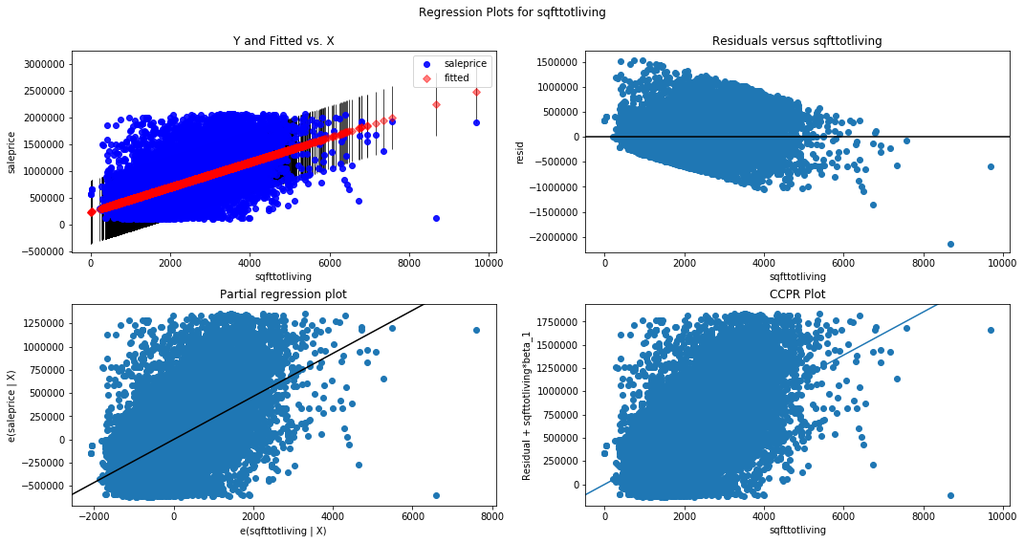

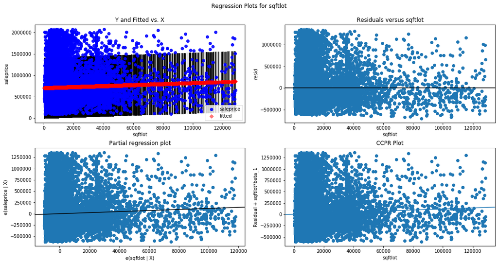

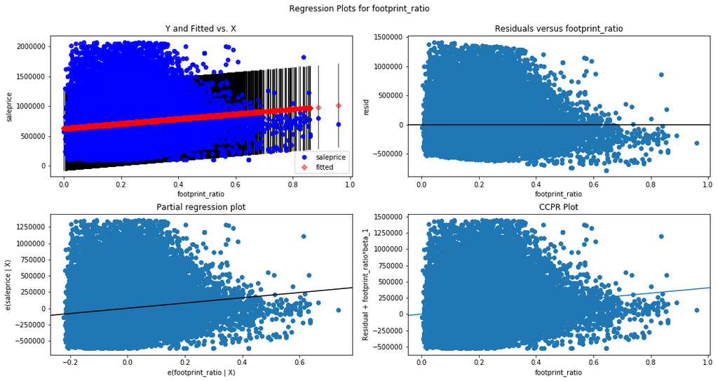

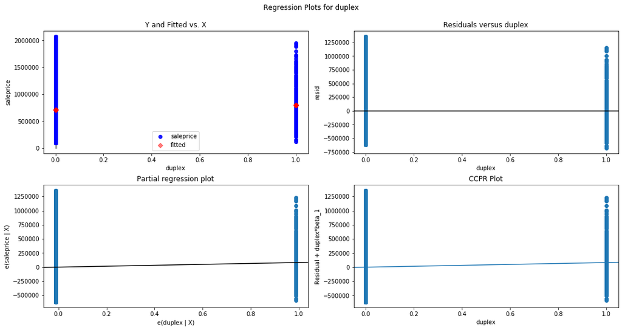

```python
kc.check_feature_heteros(baseline_features, x, y)
```

### Because the sqftlot feature seems to violoate assumption of linearity, lets remove it from the model

```python
baseline_features = ['sqfttotliving','footprint_ratio','duplex']
kc.make_housing_model(baseline_features, x, y)
```

OLS Regression Results

| Dep. Variable: | saleprice | R-squared: | 0.320 |
| --- | --- | --- | --- |
| Model: | OLS | Adj. R-squared: | 0.320 |
| Method: | Least Squares | F-statistic: | 4369. |
| Date: | Fri, 06 Dec 2019 | Prob (F-statistic): | 0.00 |
| Time: | 12:20:04 | Log-Likelihood: | -3.8999e+05 |
| No. Observations: | 27811 | AIC: | 7.800e+05 |
| Df Residuals: | 27807 | BIC: | 7.800e+05 |
| Df Model: | 3 |  |  |
| Covariance Type: | nonrobust |  |  |

|  | coef | std err | t | P>\|t\| | [0.025 | 0.975] |
| --- | --- | --- | --- | --- | --- | --- |
| const | 1.792e+05 | 5486.653 | 32.653 | 0.000 | 1.68e+05 | 1.9e+05 |
| sqfttotliving | 228.5625 | 2.059 | 111.005 | 0.000 | 224.527 | 232.598 |
| footprint_ratio | 2.742e+05 | 1.47e+04 | 18.645 | 0.000 | 2.45e+05 | 3.03e+05 |
| duplex | 6.624e+04 | 1.62e+04 | 4.094 | 0.000 | 3.45e+04 | 9.8e+04 |

| Omnibus: | 3191.837 | Durbin-Watson: | 0.870 |
| --- | --- | --- | --- |
| Prob(Omnibus): | 0.000 | Jarque-Bera (JB): | 5568.358 |
| Skew: | 0.784 | Prob(JB): | 0.00 |
| Kurtosis: | 4.532 | Cond. No. | 2.04e+04 |

Warnings:  
[1] Standard Errors assume that the covariance matrix of the errors is correctly specified.  
[2] The condition number is large, 2.04e+04. This might indicate that there are  
strong multicollinearity or other numerical problems.

# All RE listings include bath count, so lets see how that contributes to our model:

```python
list_of_feat =['bath_total_count', 'sqfttotliving','footprint_ratio','duplex']
kc.make_housing_model(list_of_feat,kc.engineer_total_baths(x),y)
```

OLS Regression Results

| Dep. Variable: | saleprice | R-squared: | 0.320 |
| --- | --- | --- | --- |
| Model: | OLS | Adj. R-squared: | 0.320 |
| Method: | Least Squares | F-statistic: | 3276. |
| Date: | Fri, 06 Dec 2019 | Prob (F-statistic): | 0.00 |
| Time: | 12:20:05 | Log-Likelihood: | -3.8999e+05 |
| No. Observations: | 27811 | AIC: | 7.800e+05 |
| Df Residuals: | 27806 | BIC: | 7.800e+05 |
| Df Model: | 4 |  |  |
| Covariance Type: | nonrobust |  |  |

|  | coef | std err | t | P>\|t\| | [0.025 | 0.975] |
| --- | --- | --- | --- | --- | --- | --- |
| const | 1.797e+05 | 5713.060 | 31.451 | 0.000 | 1.68e+05 | 1.91e+05 |
| bath_total_count | -969.5505 | 2932.696 | -0.331 | 0.741 | -6717.778 | 4778.677 |
| sqfttotliving | 229.3357 | 3.116 | 73.601 | 0.000 | 223.228 | 235.443 |
| footprint_ratio | 2.756e+05 | 1.53e+04 | 17.990 | 0.000 | 2.46e+05 | 3.06e+05 |
| duplex | 6.63e+04 | 1.62e+04 | 4.097 | 0.000 | 3.46e+04 | 9.8e+04 |

| Omnibus: | 3191.912 | Durbin-Watson: | 0.870 |
| --- | --- | --- | --- |
| Prob(Omnibus): | 0.000 | Jarque-Bera (JB): | 5569.841 |
| Skew: | 0.784 | Prob(JB): | 0.00 |
| Kurtosis: | 4.532 | Cond. No. | 2.04e+04 |

Warnings:  
[1] Standard Errors assume that the covariance matrix of the errors is correctly specified.  
[2] The condition number is large, 2.04e+04. This might indicate that there are  
strong multicollinearity or other numerical problems.

### Total bathrooms does not seem to add much benefit to our model, and it has an elevated p score, so we will not include it in our model.

# What about the age of the house?

```python
list_of_feat =['sqfttotliving','footprint_ratio','duplex', 'age']
kc.make_housing_model(list_of_feat,kc.engineer_age(x),y)
```

OLS Regression Results

| Dep. Variable: | saleprice | R-squared: | 0.342 |
| --- | --- | --- | --- |
| Model: | OLS | Adj. R-squared: | 0.342 |
| Method: | Least Squares | F-statistic: | 3620. |
| Date: | Fri, 06 Dec 2019 | Prob (F-statistic): | 0.00 |
| Time: | 12:20:06 | Log-Likelihood: | -3.8954e+05 |
| No. Observations: | 27811 | AIC: | 7.791e+05 |
| Df Residuals: | 27806 | BIC: | 7.791e+05 |
| Df Model: | 4 |  |  |
| Covariance Type: | nonrobust |  |  |

|  | coef | std err | t | P>\|t\| | [0.025 | 0.975] |
| --- | --- | --- | --- | --- | --- | --- |
| const | -9252.1461 | 8194.532 | -1.129 | 0.259 | -2.53e+04 | 6809.541 |
| sqfttotliving | 255.8034 | 2.213 | 115.596 | 0.000 | 251.466 | 260.141 |
| footprint_ratio | 4.78e+05 | 1.59e+04 | 30.009 | 0.000 | 4.47e+05 | 5.09e+05 |
| duplex | 4306.2370 | 1.6e+04 | 0.268 | 0.788 | -2.71e+04 | 3.58e+04 |
| age | 2047.8086 | 67.023 | 30.554 | 0.000 | 1916.441 | 2179.177 |

| Omnibus: | 3401.034 | Durbin-Watson: | 0.938 |
| --- | --- | --- | --- |
| Prob(Omnibus): | 0.000 | Jarque-Bera (JB): | 6900.107 |
| Skew: | 0.772 | Prob(JB): | 0.00 |
| Kurtosis: | 4.890 | Cond. No. | 2.20e+04 |

Warnings:  
[1] Standard Errors assume that the covariance matrix of the errors is correctly specified.  
[2] The condition number is large, 2.2e+04. This might indicate that there are  
strong multicollinearity or other numerical problems.

### Age seems to add a notible boost in the model,and it has a low p score, lets test its assumptions:

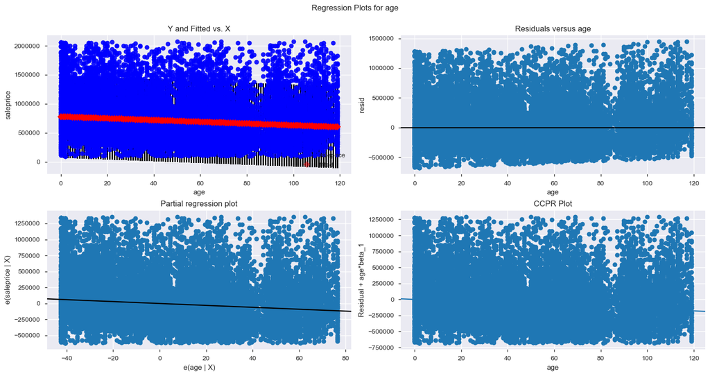

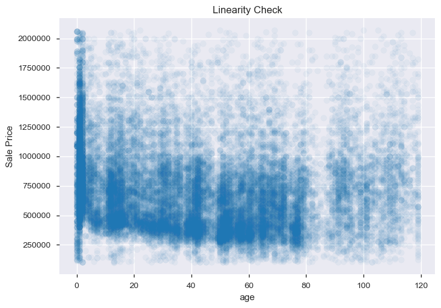

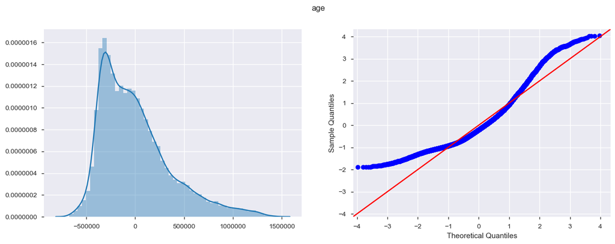

```python
kc.check_feature_heteros(['age'],x,y)
kc.check_feature_linearity(['age'],x,y)
kc.check_feature_resid_dist(['age'],x,y)
```

### It appears that age violates the assumption of linearity, so although it adds some strength to out R^2 value, we will leave it out of our improved model.

# What about porches/decks?

```python
list_of_feat =['sqfttotliving','footprint_ratio','duplex', 'porch_sqft_total']
kc.make_housing_model(list_of_feat,kc.engineer_total_porch_space(x),y)
```

OLS Regression Results

| Dep. Variable: | saleprice | R-squared: | 0.321 |
| --- | --- | --- | --- |
| Model: | OLS | Adj. R-squared: | 0.321 |
| Method: | Least Squares | F-statistic: | 3287. |
| Date: | Fri, 06 Dec 2019 | Prob (F-statistic): | 0.00 |
| Time: | 12:20:11 | Log-Likelihood: | -3.8998e+05 |
| No. Observations: | 27811 | AIC: | 7.800e+05 |
| Df Residuals: | 27806 | BIC: | 7.800e+05 |
| Df Model: | 4 |  |  |
| Covariance Type: | nonrobust |  |  |

|  | coef | std err | t | P>\|t\| | [0.025 | 0.975] |
| --- | --- | --- | --- | --- | --- | --- |
| const | 1.817e+05 | 5503.126 | 33.010 | 0.000 | 1.71e+05 | 1.92e+05 |
| sqfttotliving | 223.8325 | 2.234 | 100.186 | 0.000 | 219.453 | 228.212 |
| footprint_ratio | 2.761e+05 | 1.47e+04 | 18.777 | 0.000 | 2.47e+05 | 3.05e+05 |
| duplex | 6.724e+04 | 1.62e+04 | 4.158 | 0.000 | 3.55e+04 | 9.89e+04 |
| porch_sqft_total | 89.8408 | 16.517 | 5.439 | 0.000 | 57.466 | 122.215 |

| Omnibus: | 3167.889 | Durbin-Watson: | 0.868 |
| --- | --- | --- | --- |
| Prob(Omnibus): | 0.000 | Jarque-Bera (JB): | 5517.724 |
| Skew: | 0.780 | Prob(JB): | 0.00 |
| Kurtosis: | 4.526 | Cond. No. | 2.05e+04 |

Warnings:  
[1] Standard Errors assume that the covariance matrix of the errors is correctly specified.  
[2] The condition number is large, 2.05e+04. This might indicate that there are  
strong multicollinearity or other numerical problems.

The R^2 value remains unchanged, and the porch feature's coefficient is relativley small, so we will not include it in the model.

# How about zipcode?

```python
#create model with zipcodes and other baseline features

list_of_feat =['sqfttotliving','footprint_ratio','duplex']
kc.make_zipcode_model(df_clean, list_of_feat)
```

OLS Regression Results

| Dep. Variable: | saleprice | R-squared: | 0.710 |
| --- | --- | --- | --- |
| Model: | OLS | Adj. R-squared: | 0.709 |
| Method: | Least Squares | F-statistic: | 663.6 |
| Date: | Fri, 06 Dec 2019 | Prob (F-statistic): | 0.00 |
| Time: | 12:20:15 | Log-Likelihood: | -3.0950e+05 |
| No. Observations: | 22802 | AIC: | 6.192e+05 |
| Df Residuals: | 22717 | BIC: | 6.199e+05 |
| Df Model: | 84 |  |  |
| Covariance Type: | nonrobust |  |  |

|  | coef | std err | t | P>\|t\| | [0.025 | 0.975] |
| --- | --- | --- | --- | --- | --- | --- |
| const | 7.041e+05 | 1.9e+05 | 3.699 | 0.000 | 3.31e+05 | 1.08e+06 |
| zip_98001 | -6.853e+05 | 1.9e+05 | -3.598 | 0.000 | -1.06e+06 | -3.12e+05 |
| zip_98002 | -6.676e+05 | 1.91e+05 | -3.503 | 0.000 | -1.04e+06 | -2.94e+05 |
| zip_98003 | -6.681e+05 | 1.91e+05 | -3.507 | 0.000 | -1.04e+06 | -2.95e+05 |
| zip_98004 | 2.208e+05 | 1.91e+05 | 1.156 | 0.248 | -1.54e+05 | 5.95e+05 |
| zip_98005 | -1.118e+04 | 1.91e+05 | -0.059 | 0.953 | -3.86e+05 | 3.63e+05 |
| zip_98006 | -1.258e+05 | 1.9e+05 | -0.661 | 0.509 | -4.99e+05 | 2.48e+05 |
| zip_98007 | -2.103e+05 | 1.91e+05 | -1.101 | 0.271 | -5.85e+05 | 1.64e+05 |
| zip_98008 | -2.154e+05 | 1.91e+05 | -1.130 | 0.258 | -5.89e+05 | 1.58e+05 |
| zip_98009 | -6.642e+05 | 2.69e+05 | -2.468 | 0.014 | -1.19e+06 | -1.37e+05 |
| zip_98010 | -5.693e+05 | 1.91e+05 | -2.978 | 0.003 | -9.44e+05 | -1.95e+05 |
| zip_98011 | -4.215e+05 | 1.91e+05 | -2.210 | 0.027 | -7.95e+05 | -4.76e+04 |
| zip_98014 | -5.065e+05 | 1.91e+05 | -2.650 | 0.008 | -8.81e+05 | -1.32e+05 |
| zip_98019 | -5.216e+05 | 1.91e+05 | -2.732 | 0.006 | -8.96e+05 | -1.47e+05 |
| zip_98022 | -6.557e+05 | 1.91e+05 | -3.440 | 0.001 | -1.03e+06 | -2.82e+05 |
| zip_98023 | -6.851e+05 | 1.9e+05 | -3.598 | 0.000 | -1.06e+06 | -3.12e+05 |
| zip_98024 | -4.879e+05 | 1.92e+05 | -2.539 | 0.011 | -8.65e+05 | -1.11e+05 |
| zip_98027 | -3.335e+05 | 1.91e+05 | -1.749 | 0.080 | -7.07e+05 | 4.01e+04 |
| zip_98028 | -4.471e+05 | 1.91e+05 | -2.345 | 0.019 | -8.21e+05 | -7.34e+04 |
| zip_98029 | -2.43e+05 | 1.91e+05 | -1.274 | 0.203 | -6.17e+05 | 1.31e+05 |
| zip_98030 | -6.525e+05 | 1.91e+05 | -3.423 | 0.001 | -1.03e+06 | -2.79e+05 |
| zip_98031 | -6.47e+05 | 1.91e+05 | -3.395 | 0.001 | -1.02e+06 | -2.73e+05 |
| zip_98032 | -6.631e+05 | 1.91e+05 | -3.477 | 0.001 | -1.04e+06 | -2.89e+05 |
| zip_98033 | 1.326e+04 | 1.91e+05 | 0.070 | 0.945 | -3.6e+05 | 3.87e+05 |
| zip_98034 | -3.213e+05 | 1.9e+05 | -1.687 | 0.092 | -6.95e+05 | 5.21e+04 |
| zip_98038 | -6.026e+05 | 1.9e+05 | -3.164 | 0.002 | -9.76e+05 | -2.29e+05 |
| zip_98039 | 4.537e+05 | 1.97e+05 | 2.309 | 0.021 | 6.85e+04 | 8.39e+05 |
| zip_98040 | 1.411e+05 | 1.91e+05 | 0.740 | 0.459 | -2.33e+05 | 5.15e+05 |
| zip_98042 | -6.482e+05 | 1.9e+05 | -3.404 | 0.001 | -1.02e+06 | -2.75e+05 |
| zip_98045 | -4.43e+05 | 1.91e+05 | -2.325 | 0.020 | -8.17e+05 | -6.95e+04 |

[output cut: 55 more lines]

| Omnibus: | 4018.111 | Durbin-Watson: | 1.531 |
| --- | --- | --- | --- |
| Prob(Omnibus): | 0.000 | Jarque-Bera (JB): | 55180.288 |
| Skew: | 0.436 | Prob(JB): | 0.00 |
| Kurtosis: | 10.571 | Cond. No. | 2.93e+06 |

Warnings:  
[1] Standard Errors assume that the covariance matrix of the errors is correctly specified.  
[2] The condition number is large, 2.93e+06. This might indicate that there are  
strong multicollinearity or other numerical problems.

### LOCATION LOCATION LOCATION wow, that added a bunch to our R^2! Lets check the assumptions:

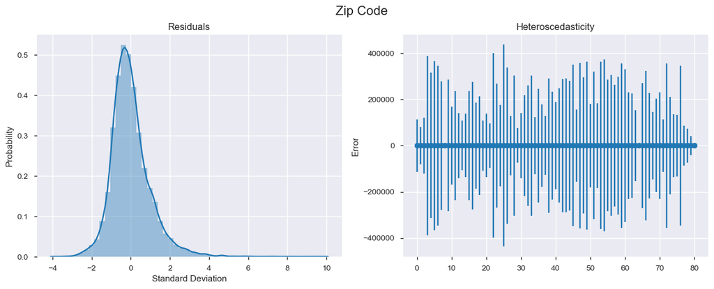

```python
kc.check_zip_code_res_normality(df_clean)
```

Great, Zip Codes seem to meet our assumptions, lets include them !

# We now added features relating to views, the best predicting waterfront feature, as well as heatsource and the surface of the access street

We tried a model with ALL features not dropped by our cleaning function, and a few stood out. We wanted to explore the street surface and heatsource features, as they were categorical. Upon looking closely at them, they didn't actually improve our R^2 when added alongside the view and waterfront features. And when dropping them, they did not decrease our ability to predict

We did not include some view features based on assumptions and correlation. For example, houses in King County that have views of Pugent Sound are expected to also have views of the Olympics. The Olympics proved to be a better predictor so we used that instead of the Puget Sound feature. The values for all of the view features are continuous, no view is 0, fair is 1, excellent is 4.

```python
## This is our list of features for the new model
new_model = df_clean[['saleprice','sqfttotliving', 'footprint_ratio', 'duplex', 'wfntlocation', 'lakesammamish', 'seattleskyline', 'olympics', 'mtrainier', 'streetsurface', 'heatsource', 'zipcode']]
```

```python
# this one hot encodes the zipcode column
zip_df = kc.zip_code_df(new_model)[0]
```

```python
# below is our new model with the One Hot Encoded zip codes
import statsmodels.api as sm
Y = zip_df['saleprice']
X = zip_df.drop(['saleprice'], axis=1)
X_int = sm.add_constant(X)
model = sm.OLS(Y, X_int).fit()
model.summary()
```

OLS Regression Results

| Dep. Variable: | saleprice | R-squared: | 0.722 |
| --- | --- | --- | --- |
| Model: | OLS | Adj. R-squared: | 0.721 |
| Method: | Least Squares | F-statistic: | 648.8 |
| Date: | Fri, 06 Dec 2019 | Prob (F-statistic): | 0.00 |
| Time: | 12:20:30 | Log-Likelihood: | -3.0903e+05 |
| No. Observations: | 22802 | AIC: | 6.182e+05 |
| Df Residuals: | 22710 | BIC: | 6.190e+05 |
| Df Model: | 91 |  |  |
| Covariance Type: | nonrobust |  |  |

|  | coef | std err | t | P>\|t\| | [0.025 | 0.975] |
| --- | --- | --- | --- | --- | --- | --- |
| const | 7.135e+05 | 1.87e+05 | 3.822 | 0.000 | 3.48e+05 | 1.08e+06 |
| sqfttotliving | 196.2514 | 1.682 | 116.708 | 0.000 | 192.955 | 199.547 |
| footprint_ratio | -1.093e+05 | 1.33e+04 | -8.194 | 0.000 | -1.35e+05 | -8.32e+04 |
| duplex | -1.121e+04 | 1.05e+04 | -1.069 | 0.285 | -3.18e+04 | 9352.987 |
| wfntlocation | 2.185e+04 | 1507.072 | 14.499 | 0.000 | 1.89e+04 | 2.48e+04 |
| lakesammamish | 1.035e+05 | 8052.102 | 12.852 | 0.000 | 8.77e+04 | 1.19e+05 |
| seattleskyline | 3.3e+04 | 6898.149 | 4.783 | 0.000 | 1.95e+04 | 4.65e+04 |
| olympics | 6.929e+04 | 3396.864 | 20.400 | 0.000 | 6.26e+04 | 7.6e+04 |
| mtrainier | 2.142e+04 | 5634.343 | 3.802 | 0.000 | 1.04e+04 | 3.25e+04 |
| streetsurface | 7173.2331 | 7577.977 | 0.947 | 0.344 | -7680.121 | 2.2e+04 |
| heatsource | 648.5051 | 2135.658 | 0.304 | 0.761 | -3537.530 | 4834.541 |
| zip_98001 | -7.025e+05 | 1.87e+05 | -3.764 | 0.000 | -1.07e+06 | -3.37e+05 |
| zip_98002 | -6.86e+05 | 1.87e+05 | -3.675 | 0.000 | -1.05e+06 | -3.2e+05 |
| zip_98003 | -6.914e+05 | 1.87e+05 | -3.704 | 0.000 | -1.06e+06 | -3.26e+05 |
| zip_98004 | 2.128e+05 | 1.87e+05 | 1.137 | 0.255 | -1.54e+05 | 5.8e+05 |
| zip_98005 | -1.848e+04 | 1.87e+05 | -0.099 | 0.921 | -3.85e+05 | 3.48e+05 |
| zip_98006 | -1.603e+05 | 1.87e+05 | -0.859 | 0.390 | -5.26e+05 | 2.06e+05 |
| zip_98007 | -2.203e+05 | 1.87e+05 | -1.177 | 0.239 | -5.87e+05 | 1.47e+05 |
| zip_98008 | -2.599e+05 | 1.87e+05 | -1.392 | 0.164 | -6.26e+05 | 1.06e+05 |
| zip_98009 | -6.723e+05 | 2.64e+05 | -2.550 | 0.011 | -1.19e+06 | -1.55e+05 |
| zip_98010 | -6.088e+05 | 1.87e+05 | -3.250 | 0.001 | -9.76e+05 | -2.42e+05 |
| zip_98011 | -4.332e+05 | 1.87e+05 | -2.318 | 0.020 | -8e+05 | -6.69e+04 |
| zip_98014 | -5.297e+05 | 1.87e+05 | -2.828 | 0.005 | -8.97e+05 | -1.63e+05 |
| zip_98019 | -5.375e+05 | 1.87e+05 | -2.874 | 0.004 | -9.04e+05 | -1.71e+05 |
| zip_98022 | -6.75e+05 | 1.87e+05 | -3.614 | 0.000 | -1.04e+06 | -3.09e+05 |
| zip_98023 | -7.027e+05 | 1.87e+05 | -3.767 | 0.000 | -1.07e+06 | -3.37e+05 |
| zip_98024 | -5.144e+05 | 1.88e+05 | -2.732 | 0.006 | -8.83e+05 | -1.45e+05 |
| zip_98027 | -3.435e+05 | 1.87e+05 | -1.839 | 0.066 | -7.1e+05 | 2.25e+04 |
| zip_98028 | -4.589e+05 | 1.87e+05 | -2.457 | 0.014 | -8.25e+05 | -9.28e+04 |
| zip_98029 | -2.593e+05 | 1.87e+05 | -1.388 | 0.165 | -6.25e+05 | 1.07e+05 |

[output cut: 62 more lines]

| Omnibus: | 3736.034 | Durbin-Watson: | 1.553 |
| --- | --- | --- | --- |
| Prob(Omnibus): | 0.000 | Jarque-Bera (JB): | 57760.101 |
| Skew: | 0.298 | Prob(JB): | 0.00 |
| Kurtosis: | 10.774 | Cond. No. | 2.93e+06 |

Warnings:  
[1] Standard Errors assume that the covariance matrix of the errors is correctly specified.  
[2] The condition number is large, 2.93e+06. This might indicate that there are  
strong multicollinearity or other numerical problems.

### Heatsource and Streetsurface

We found that dropping both streetsurface and heatsource did not affect the predictive capacities of the model at all. This is also true after One Hot Encoding them (not contained in this workbook)

```python
# this drops streetsurface and heatsource, to demonstrate that it does not affect our model
Y = zip_df['saleprice']
X = zip_df.drop(['saleprice', 'streetsurface', 'heatsource'], axis=1)
X_int = sm.add_constant(X)
model = sm.OLS(Y, X_int).fit()
model.summary()
```

OLS Regression Results

| Dep. Variable: | saleprice | R-squared: | 0.722 |
| --- | --- | --- | --- |
| Model: | OLS | Adj. R-squared: | 0.721 |
| Method: | Least Squares | F-statistic: | 663.4 |
| Date: | Fri, 06 Dec 2019 | Prob (F-statistic): | 0.00 |
| Time: | 12:20:34 | Log-Likelihood: | -3.0903e+05 |
| No. Observations: | 22802 | AIC: | 6.182e+05 |
| Df Residuals: | 22712 | BIC: | 6.190e+05 |
| Df Model: | 89 |  |  |
| Covariance Type: | nonrobust |  |  |

|  | coef | std err | t | P>\|t\| | [0.025 | 0.975] |
| --- | --- | --- | --- | --- | --- | --- |
| const | 7.221e+05 | 1.86e+05 | 3.873 | 0.000 | 3.57e+05 | 1.09e+06 |
| sqfttotliving | 196.2530 | 1.679 | 116.899 | 0.000 | 192.962 | 199.544 |
| footprint_ratio | -1.11e+05 | 1.32e+04 | -8.403 | 0.000 | -1.37e+05 | -8.51e+04 |
| duplex | -1.099e+04 | 1.05e+04 | -1.048 | 0.295 | -3.15e+04 | 9557.660 |
| wfntlocation | 2.193e+04 | 1504.982 | 14.569 | 0.000 | 1.9e+04 | 2.49e+04 |
| lakesammamish | 1.034e+05 | 8048.399 | 12.843 | 0.000 | 8.76e+04 | 1.19e+05 |
| seattleskyline | 3.3e+04 | 6897.907 | 4.784 | 0.000 | 1.95e+04 | 4.65e+04 |
| olympics | 6.929e+04 | 3396.774 | 20.397 | 0.000 | 6.26e+04 | 7.59e+04 |
| mtrainier | 2.158e+04 | 5632.105 | 3.831 | 0.000 | 1.05e+04 | 3.26e+04 |
| zip_98001 | -7.016e+05 | 1.87e+05 | -3.760 | 0.000 | -1.07e+06 | -3.36e+05 |
| zip_98002 | -6.858e+05 | 1.87e+05 | -3.674 | 0.000 | -1.05e+06 | -3.2e+05 |
| zip_98003 | -6.91e+05 | 1.87e+05 | -3.702 | 0.000 | -1.06e+06 | -3.25e+05 |
| zip_98004 | 2.127e+05 | 1.87e+05 | 1.137 | 0.256 | -1.54e+05 | 5.8e+05 |
| zip_98005 | -1.835e+04 | 1.87e+05 | -0.098 | 0.922 | -3.85e+05 | 3.48e+05 |
| zip_98006 | -1.6e+05 | 1.87e+05 | -0.858 | 0.391 | -5.26e+05 | 2.06e+05 |
| zip_98007 | -2.2e+05 | 1.87e+05 | -1.176 | 0.240 | -5.87e+05 | 1.47e+05 |
| zip_98008 | -2.596e+05 | 1.87e+05 | -1.390 | 0.164 | -6.26e+05 | 1.06e+05 |
| zip_98009 | -6.718e+05 | 2.64e+05 | -2.548 | 0.011 | -1.19e+06 | -1.55e+05 |
| zip_98010 | -6.079e+05 | 1.87e+05 | -3.245 | 0.001 | -9.75e+05 | -2.41e+05 |
| zip_98011 | -4.329e+05 | 1.87e+05 | -2.316 | 0.021 | -7.99e+05 | -6.66e+04 |
| zip_98014 | -5.291e+05 | 1.87e+05 | -2.825 | 0.005 | -8.96e+05 | -1.62e+05 |
| zip_98019 | -5.365e+05 | 1.87e+05 | -2.869 | 0.004 | -9.03e+05 | -1.7e+05 |
| zip_98022 | -6.744e+05 | 1.87e+05 | -3.611 | 0.000 | -1.04e+06 | -3.08e+05 |
| zip_98023 | -7.023e+05 | 1.87e+05 | -3.765 | 0.000 | -1.07e+06 | -3.37e+05 |
| zip_98024 | -5.137e+05 | 1.88e+05 | -2.728 | 0.006 | -8.83e+05 | -1.45e+05 |
| zip_98027 | -3.425e+05 | 1.87e+05 | -1.834 | 0.067 | -7.09e+05 | 2.35e+04 |
| zip_98028 | -4.586e+05 | 1.87e+05 | -2.456 | 0.014 | -8.25e+05 | -9.26e+04 |
| zip_98029 | -2.589e+05 | 1.87e+05 | -1.386 | 0.166 | -6.25e+05 | 1.07e+05 |
| zip_98030 | -6.639e+05 | 1.87e+05 | -3.555 | 0.000 | -1.03e+06 | -2.98e+05 |
| zip_98031 | -6.591e+05 | 1.87e+05 | -3.530 | 0.000 | -1.02e+06 | -2.93e+05 |

[output cut: 60 more lines]

| Omnibus: | 3739.942 | Durbin-Watson: | 1.553 |
| --- | --- | --- | --- |
| Prob(Omnibus): | 0.000 | Jarque-Bera (JB): | 57809.956 |
| Skew: | 0.300 | Prob(JB): | 0.00 |
| Kurtosis: | 10.777 | Cond. No. | 2.93e+06 |

Warnings:  
[1] Standard Errors assume that the covariance matrix of the errors is correctly specified.  
[2] The condition number is large, 2.93e+06. This might indicate that there are  
strong multicollinearity or other numerical problems.

## Waterfront Location (wfntlocation) is categorical, let's One Hot Encode it!

```python
def waterfront_ohe(final_model_df):
    """this is similar to the zipcode OHE function, but for the waterfront location feature"""
    final_model_df['wfntlocation'] = pd.Categorical(final_model_df['wfntlocation'])
    df_water = pd.get_dummies(final_model_df['wfntlocation'], prefix = 'water')

    #drop the column for houses with no waterfront location
    df_water.drop(columns = 'water_0.0', inplace = True)


#join the zip code dataframe to the dataframe with the other predicitive features
    df_with_water_cols = final_model_df.join(df_water, how = 'inner')
    df_with_water_cols = df_with_water_cols.drop(['wfntlocation'], axis=1)
    return df_with_water_cols
```

```python
model_with_wfnt_ohe = waterfront_ohe(zip_df)
```

```python
Y = model_with_wfnt_ohe['saleprice']
X = model_with_wfnt_ohe.drop(['saleprice'], axis=1)
X_int = sm.add_constant(X)
model = sm.OLS(Y, X_int).fit()
model.summary()
```

OLS Regression Results

| Dep. Variable: | saleprice | R-squared: | 0.727 |
| --- | --- | --- | --- |
| Model: | OLS | Adj. R-squared: | 0.726 |
| Method: | Least Squares | F-statistic: | 622.9 |
| Date: | Fri, 06 Dec 2019 | Prob (F-statistic): | 0.00 |
| Time: | 12:20:37 | Log-Likelihood: | -3.0883e+05 |
| No. Observations: | 22802 | AIC: | 6.179e+05 |
| Df Residuals: | 22704 | BIC: | 6.187e+05 |
| Df Model: | 97 |  |  |
| Covariance Type: | nonrobust |  |  |

|  | coef | std err | t | P>\|t\| | [0.025 | 0.975] |
| --- | --- | --- | --- | --- | --- | --- |
| const | 7.107e+05 | 1.85e+05 | 3.839 | 0.000 | 3.48e+05 | 1.07e+06 |
| sqfttotliving | 195.7272 | 1.669 | 117.247 | 0.000 | 192.455 | 198.999 |
| footprint_ratio | -1.098e+05 | 1.32e+04 | -8.302 | 0.000 | -1.36e+05 | -8.39e+04 |
| duplex | -1.579e+04 | 1.04e+04 | -1.516 | 0.129 | -3.62e+04 | 4617.416 |
| lakesammamish | 1.121e+05 | 9123.066 | 12.283 | 0.000 | 9.42e+04 | 1.3e+05 |
| seattleskyline | 3.618e+04 | 6849.115 | 5.283 | 0.000 | 2.28e+04 | 4.96e+04 |
| olympics | 6.422e+04 | 3425.670 | 18.747 | 0.000 | 5.75e+04 | 7.09e+04 |
| mtrainier | 1.708e+04 | 5614.943 | 3.041 | 0.002 | 6070.653 | 2.81e+04 |
| streetsurface | 1.027e+04 | 7525.200 | 1.365 | 0.172 | -4475.602 | 2.5e+04 |
| heatsource | 1262.2023 | 2118.535 | 0.596 | 0.551 | -2890.272 | 5414.677 |
| zip_98001 | -7.016e+05 | 1.85e+05 | -3.791 | 0.000 | -1.06e+06 | -3.39e+05 |
| zip_98002 | -6.836e+05 | 1.85e+05 | -3.692 | 0.000 | -1.05e+06 | -3.21e+05 |
| zip_98003 | -6.907e+05 | 1.85e+05 | -3.731 | 0.000 | -1.05e+06 | -3.28e+05 |
| zip_98004 | 2.132e+05 | 1.86e+05 | 1.149 | 0.251 | -1.51e+05 | 5.77e+05 |
| zip_98005 | -1.832e+04 | 1.86e+05 | -0.099 | 0.921 | -3.82e+05 | 3.45e+05 |
| zip_98006 | -1.629e+05 | 1.85e+05 | -0.880 | 0.379 | -5.26e+05 | 2e+05 |
| zip_98007 | -2.206e+05 | 1.86e+05 | -1.188 | 0.235 | -5.84e+05 | 1.43e+05 |
| zip_98008 | -2.597e+05 | 1.85e+05 | -1.402 | 0.161 | -6.23e+05 | 1.03e+05 |
| zip_98009 | -6.718e+05 | 2.61e+05 | -2.569 | 0.010 | -1.18e+06 | -1.59e+05 |
| zip_98010 | -6.017e+05 | 1.86e+05 | -3.239 | 0.001 | -9.66e+05 | -2.38e+05 |
| zip_98011 | -4.321e+05 | 1.85e+05 | -2.332 | 0.020 | -7.95e+05 | -6.89e+04 |
| zip_98014 | -5.236e+05 | 1.86e+05 | -2.819 | 0.005 | -8.88e+05 | -1.6e+05 |
| zip_98019 | -5.365e+05 | 1.85e+05 | -2.892 | 0.004 | -9e+05 | -1.73e+05 |
| zip_98022 | -6.742e+05 | 1.85e+05 | -3.640 | 0.000 | -1.04e+06 | -3.11e+05 |
| zip_98023 | -7.04e+05 | 1.85e+05 | -3.805 | 0.000 | -1.07e+06 | -3.41e+05 |
| zip_98024 | -5.033e+05 | 1.87e+05 | -2.696 | 0.007 | -8.69e+05 | -1.37e+05 |
| zip_98027 | -3.432e+05 | 1.85e+05 | -1.853 | 0.064 | -7.06e+05 | 1.98e+04 |
| zip_98028 | -4.6e+05 | 1.85e+05 | -2.483 | 0.013 | -8.23e+05 | -9.69e+04 |
| zip_98029 | -2.592e+05 | 1.85e+05 | -1.399 | 0.162 | -6.22e+05 | 1.04e+05 |
| zip_98030 | -6.648e+05 | 1.85e+05 | -3.590 | 0.000 | -1.03e+06 | -3.02e+05 |

[output cut: 68 more lines]

| Omnibus: | 3629.225 | Durbin-Watson: | 1.561 |
| --- | --- | --- | --- |
| Prob(Omnibus): | 0.000 | Jarque-Bera (JB): | 56241.477 |
| Skew: | 0.258 | Prob(JB): | 0.00 |
| Kurtosis: | 10.677 | Cond. No. | 2.93e+06 |

Warnings:  
[1] Standard Errors assume that the covariance matrix of the errors is correctly specified.  
[2] The condition number is large, 2.93e+06. This might indicate that there are  
strong multicollinearity or other numerical problems.

However, we found that the error of the Waterfront Location to be too large given the modest predictability it provides (0.005), so we have decided to not include them in the final model

Now we need to test the assumptions of these new features

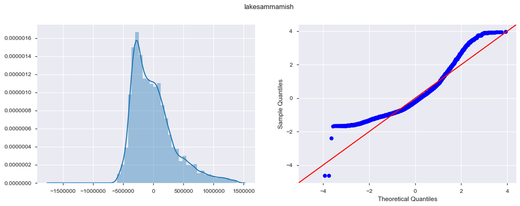

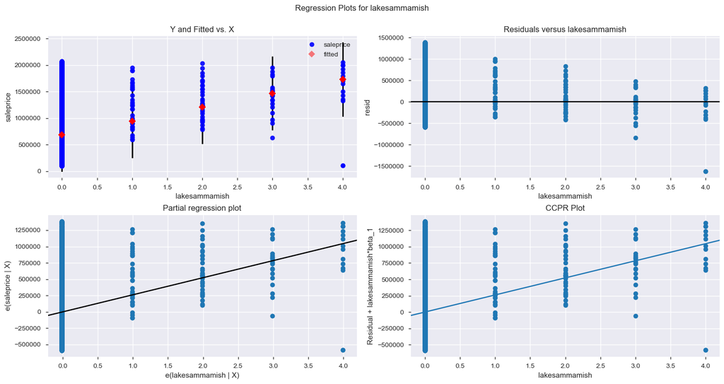

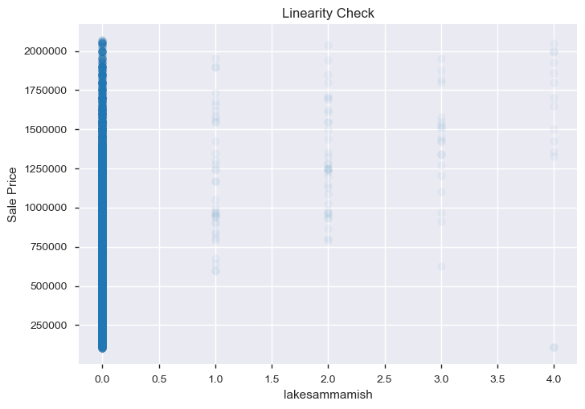

```python
# this displays the normality assumption tests for lakesammamish
kc.check_feature_resid_dist(['lakesammamish'],X, Y)
kc.check_feature_heteros(['lakesammamish'], X, Y)
kc.check_feature_linearity(['lakesammamish'], X, Y)
```

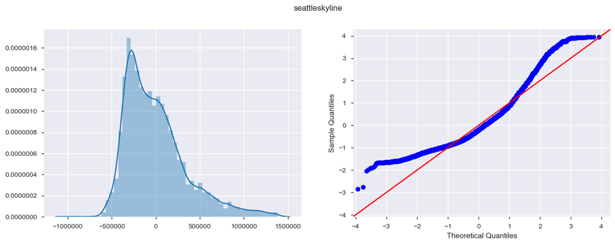

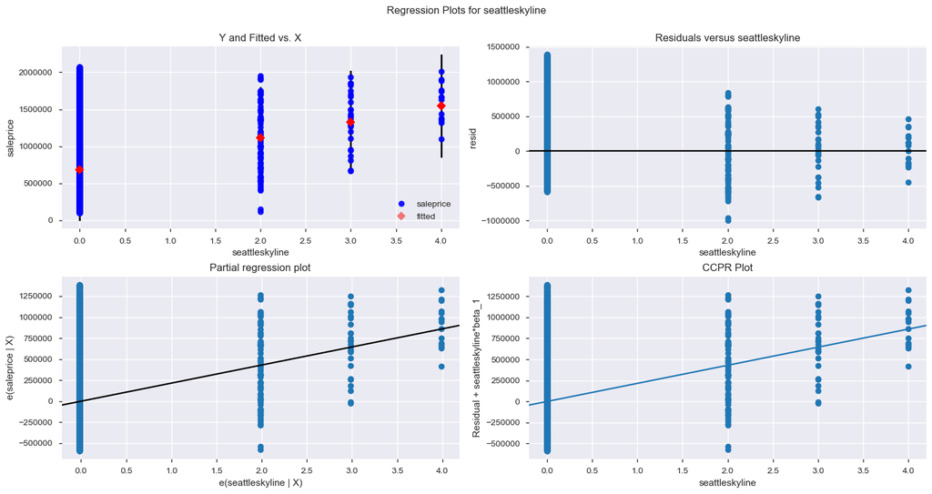

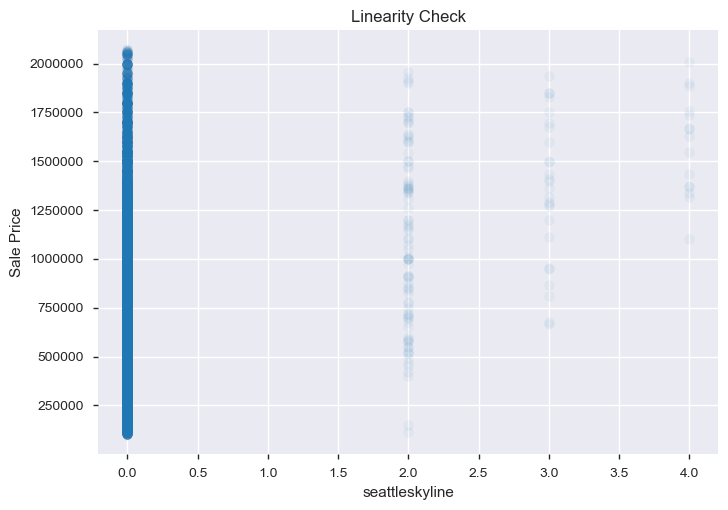

```python
# this displays the normality assumption tests for seattleskyline
kc.check_feature_resid_dist(['seattleskyline'],X, Y)
kc.check_feature_heteros(['seattleskyline'], X, Y)
kc.check_feature_linearity(['seattleskyline'], X, Y)
```

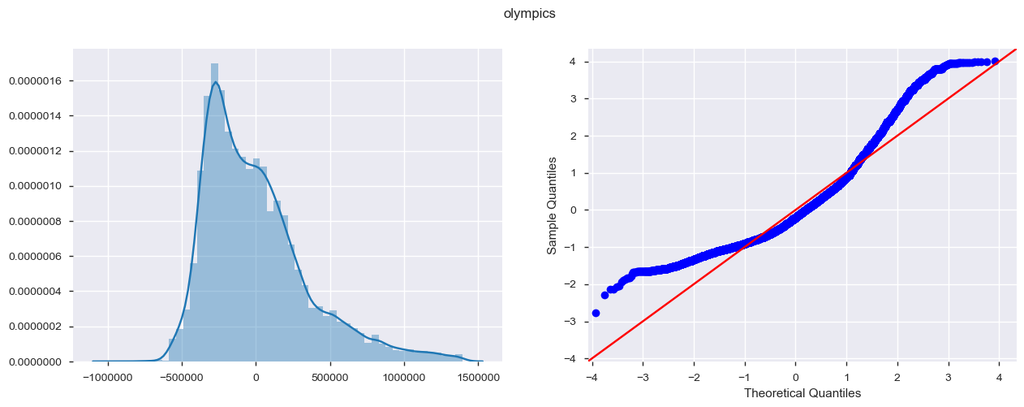

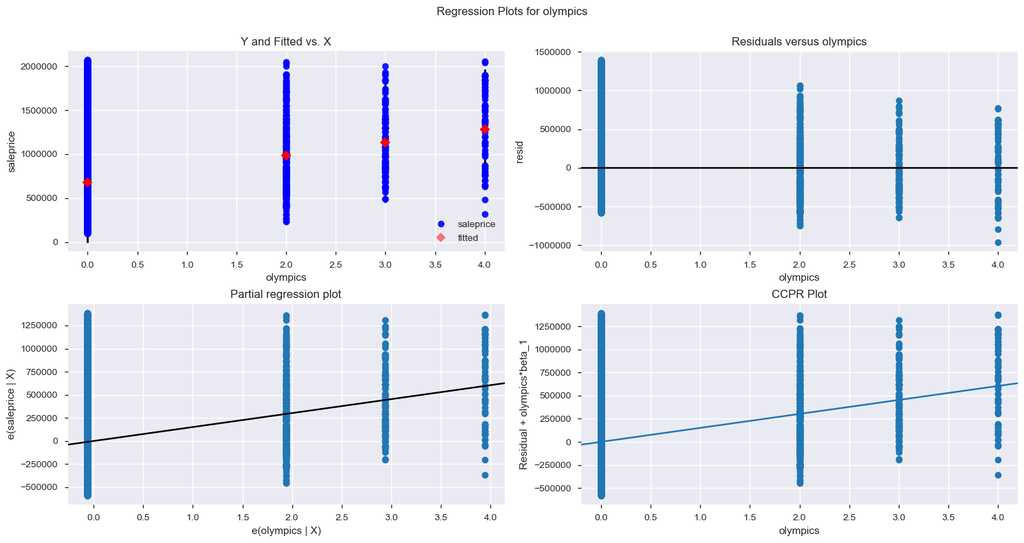

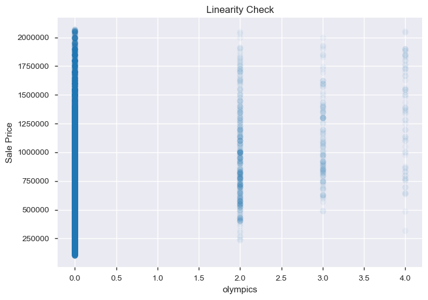

```python
# this displays the normality assumption tests for olympics
kc.check_feature_resid_dist(['olympics'],X, Y)
kc.check_feature_heteros(['olympics'], X, Y)
kc.check_feature_linearity(['olympics'], X, Y)
```

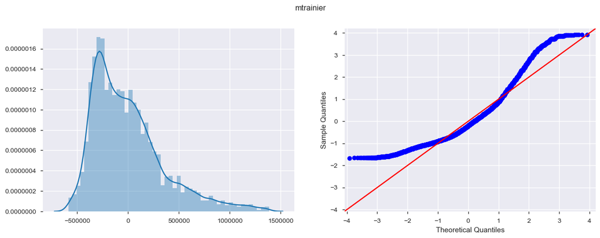

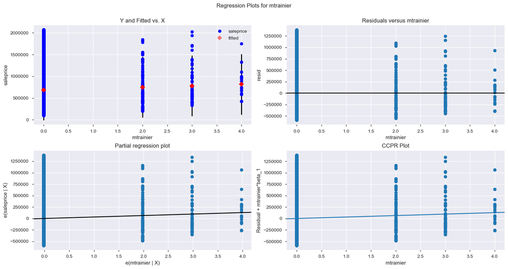

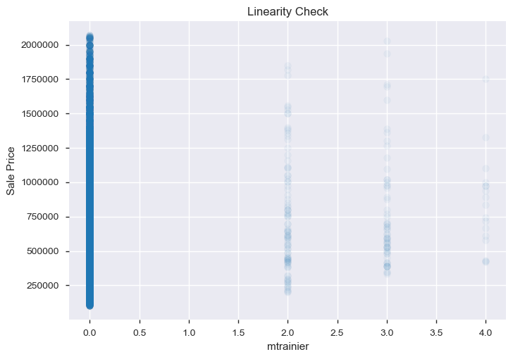

```python
# this displays the assumption tests for mtrainier feature
kc.check_feature_resid_dist(['mtrainier'],X, Y)
kc.check_feature_heteros(['mtrainier'], X, Y)
kc.check_feature_linearity(['mtrainier'], X, Y)
```

# Final Model

Below is our final linear regression model.

```python
Y = zip_df['saleprice']
X = zip_df.drop(['saleprice', 'streetsurface', 'heatsource', 'wfntlocation'], axis=1)
X_int = sm.add_constant(X)
model = sm.OLS(Y, X_int).fit()
model.summary()
```

OLS Regression Results

| Dep. Variable: | saleprice | R-squared: | 0.720 |
| --- | --- | --- | --- |
| Model: | OLS | Adj. R-squared: | 0.719 |
| Method: | Least Squares | F-statistic: | 662.3 |
| Date: | Fri, 06 Dec 2019 | Prob (F-statistic): | 0.00 |
| Time: | 12:21:00 | Log-Likelihood: | -3.0913e+05 |
| No. Observations: | 22802 | AIC: | 6.184e+05 |
| Df Residuals: | 22713 | BIC: | 6.192e+05 |
| Df Model: | 88 |  |  |
| Covariance Type: | nonrobust |  |  |

|  | coef | std err | t | P>\|t\| | [0.025 | 0.975] |
| --- | --- | --- | --- | --- | --- | --- |
| const | 7.216e+05 | 1.87e+05 | 3.852 | 0.000 | 3.54e+05 | 1.09e+06 |
| sqfttotliving | 196.9129 | 1.686 | 116.793 | 0.000 | 193.608 | 200.218 |
| footprint_ratio | -1.291e+05 | 1.32e+04 | -9.773 | 0.000 | -1.55e+05 | -1.03e+05 |
| duplex | -1.005e+04 | 1.05e+04 | -0.955 | 0.340 | -3.07e+04 | 1.06e+04 |
| lakesammamish | 1.121e+05 | 8063.383 | 13.900 | 0.000 | 9.63e+04 | 1.28e+05 |
| seattleskyline | 3.209e+04 | 6929.631 | 4.631 | 0.000 | 1.85e+04 | 4.57e+04 |
| olympics | 7.059e+04 | 3411.340 | 20.694 | 0.000 | 6.39e+04 | 7.73e+04 |
| mtrainier | 2.323e+04 | 5657.080 | 4.107 | 0.000 | 1.21e+04 | 3.43e+04 |
| zip_98001 | -6.935e+05 | 1.87e+05 | -3.699 | 0.000 | -1.06e+06 | -3.26e+05 |
| zip_98002 | -6.787e+05 | 1.88e+05 | -3.619 | 0.000 | -1.05e+06 | -3.11e+05 |
| zip_98003 | -6.873e+05 | 1.88e+05 | -3.665 | 0.000 | -1.05e+06 | -3.2e+05 |
| zip_98004 | 2.147e+05 | 1.88e+05 | 1.142 | 0.254 | -1.54e+05 | 5.83e+05 |
| zip_98005 | -1.672e+04 | 1.88e+05 | -0.089 | 0.929 | -3.85e+05 | 3.52e+05 |
| zip_98006 | -1.581e+05 | 1.87e+05 | -0.843 | 0.399 | -5.26e+05 | 2.09e+05 |
| zip_98007 | -2.173e+05 | 1.88e+05 | -1.155 | 0.248 | -5.86e+05 | 1.51e+05 |
| zip_98008 | -2.56e+05 | 1.88e+05 | -1.365 | 0.172 | -6.24e+05 | 1.12e+05 |
| zip_98009 | -6.665e+05 | 2.65e+05 | -2.516 | 0.012 | -1.19e+06 | -1.47e+05 |
| zip_98010 | -5.791e+05 | 1.88e+05 | -3.078 | 0.002 | -9.48e+05 | -2.1e+05 |
| zip_98011 | -4.285e+05 | 1.88e+05 | -2.282 | 0.022 | -7.96e+05 | -6.05e+04 |
| zip_98014 | -5.109e+05 | 1.88e+05 | -2.716 | 0.007 | -8.8e+05 | -1.42e+05 |
| zip_98019 | -5.276e+05 | 1.88e+05 | -2.808 | 0.005 | -8.96e+05 | -1.59e+05 |
| zip_98022 | -6.717e+05 | 1.88e+05 | -3.580 | 0.000 | -1.04e+06 | -3.04e+05 |
| zip_98023 | -6.981e+05 | 1.87e+05 | -3.725 | 0.000 | -1.07e+06 | -3.31e+05 |
| zip_98024 | -4.937e+05 | 1.89e+05 | -2.610 | 0.009 | -8.64e+05 | -1.23e+05 |
| zip_98027 | -3.4e+05 | 1.88e+05 | -1.813 | 0.070 | -7.08e+05 | 2.77e+04 |
| zip_98028 | -4.535e+05 | 1.88e+05 | -2.417 | 0.016 | -8.21e+05 | -8.57e+04 |
| zip_98029 | -2.547e+05 | 1.88e+05 | -1.357 | 0.175 | -6.23e+05 | 1.13e+05 |
| zip_98030 | -6.611e+05 | 1.88e+05 | -3.524 | 0.000 | -1.03e+06 | -2.93e+05 |
| zip_98031 | -6.55e+05 | 1.88e+05 | -3.492 | 0.000 | -1.02e+06 | -2.87e+05 |
| zip_98032 | -6.725e+05 | 1.88e+05 | -3.583 | 0.000 | -1.04e+06 | -3.05e+05 |

[output cut: 59 more lines]

| Omnibus: | 3872.159 | Durbin-Watson: | 1.549 |
| --- | --- | --- | --- |
| Prob(Omnibus): | 0.000 | Jarque-Bera (JB): | 57657.237 |
| Skew: | 0.361 | Prob(JB): | 0.00 |
| Kurtosis: | 10.757 | Cond. No. | 2.93e+06 |

Warnings:  
[1] Standard Errors assume that the covariance matrix of the errors is correctly specified.  
[2] The condition number is large, 2.93e+06. This might indicate that there are  
strong multicollinearity or other numerical problems.